# Individual differences

In **Pilot 1**, there are 27 subjects who did the curiosity personal trait questionaire. The following analysis will only include these subjects who had personal trait scores.

# 1 Relationship between trait score and slope of curiosity-memory relationship

## 1.1 Outside

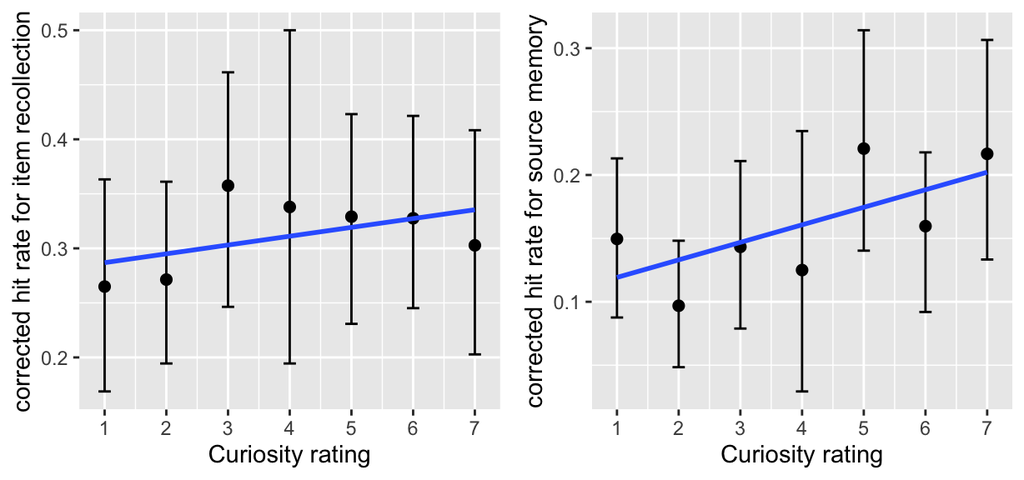

### 1.1.1 Item recollection

#### 1.1.1.1 Correlation with the average score

```
##                  Model df       AIC       BIC   logLik   Test   L.Ratio
## baseline.rating      1  3 -3.027543  6.235246 4.513772
## rating.intercept     2  4 -2.000181 10.350205 5.000090 1 vs 2 0.9726372
## rating.slope         3  6  2.000734 20.526312 4.999633 2 vs 3 0.0009145
## tr.intercept         4  7  2.426966 24.040140 5.786517 3 vs 4 1.5737682
## tr.slope             5  8  4.362379 29.063150 5.818810 4 vs 5 0.0645867
##                  p-value
## baseline.rating
## rating.intercept  0.3240
## rating.slope      0.9995
## tr.intercept      0.2097
## tr.slope          0.7994
```

#### 1.1.1.2 Correlation with the PC score

```
##                  Model df       AIC       BIC   logLik   Test   L.Ratio
## baseline.rating      1  3 -3.027543  6.235246 4.513772
## rating.intercept     2  4 -2.000181 10.350205 5.000090 1 vs 2 0.9726372
## rating.slope         3  6  2.000734 20.526312 4.999633 2 vs 3 0.0009145
## PC.intercept         4  7  2.681287 24.294462 5.659356 3 vs 4 1.3194467
## PC.slope             5  8  4.487760 29.188531 5.756120 4 vs 5 0.1935268
##                  p-value
## baseline.rating
## rating.intercept  0.3240
## rating.slope      0.9995
## PC.intercept      0.2507
## PC.slope          0.6600
```

#### 1.1.1.3 Correlation with the EC score

```
##                  Model df       AIC       BIC   logLik   Test   L.Ratio
## baseline.rating      1  3 -3.027543  6.235246 4.513772
## rating.intercept     2  4 -2.000181 10.350205 5.000090 1 vs 2 0.9726372
## rating.slope         3  6  2.000734 20.526312 4.999633 2 vs 3 0.0009145
## EC.intercept         4  7  2.860238 24.473412 5.569881 3 vs 4 1.1404963
## EC.slope             5  8  4.242632 28.943403 5.878684 4 vs 5 0.6176054
##                  p-value
## baseline.rating
## rating.intercept  0.3240
## rating.slope      0.9995
## EC.intercept      0.2855
## EC.slope          0.4319
```

### 1.1.2 Source memory

#### 1.1.2.1 Correlation with the average score

```
##                  Model df       AIC       BIC   logLik   Test  L.Ratio
## baseline.rating      1  3 -85.38795 -76.12516 45.69397
## rating.intercept     2  4 -88.29141 -75.94102 48.14570 1 vs 2 4.903460
## rating.slope         3  6 -85.88091 -67.35533 48.94046 2 vs 3 1.589505
## tr.intercept         4  7 -85.57682 -63.96364 49.78841 3 vs 4 1.695904
## tr.slope             5  8 -83.62416 -58.92339 49.81208 4 vs 5 0.047342
##                  p-value
## baseline.rating
## rating.intercept  0.0268
## rating.slope      0.4517
## tr.intercept      0.1928
## tr.slope          0.8278
```

#### 1.1.2.2 Correlation with the PC score

```
##                  Model df       AIC       BIC   logLik   Test  L.Ratio
## baseline.rating      1  3 -85.38795 -76.12516 45.69397
## rating.intercept     2  4 -88.29141 -75.94102 48.14570 1 vs 2 4.903460
## rating.slope         3  6 -85.88091 -67.35533 48.94046 2 vs 3 1.589505
## PC.intercept         4  7 -84.41765 -62.80447 49.20882 3 vs 4 0.536732
## PC.slope             5  8 -82.88433 -58.18356 49.44216 4 vs 5 0.466681
##                  p-value
## baseline.rating
## rating.intercept  0.0268
## rating.slope      0.4517
## PC.intercept      0.4638
## PC.slope          0.4945
```

#### 1.1.2.3 Correlation with the EC score

```
##                  Model df       AIC       BIC   logLik   Test  L.Ratio
## baseline.rating      1  3 -85.38795 -76.12516 45.69397
## rating.intercept     2  4 -88.29141 -75.94102 48.14570 1 vs 2 4.903460
## rating.slope         3  6 -85.88091 -67.35533 48.94046 2 vs 3 1.589505
## EC.intercept         4  7 -86.10415 -64.49097 50.05207 3 vs 4 2.223236
## EC.slope             5  8 -84.16082 -59.46005 50.08041 4 vs 5 0.056673
##                  p-value
## baseline.rating
## rating.intercept  0.0268
## rating.slope      0.4517
## EC.intercept      0.1359
## EC.slope          0.8118
```

## 1.2 Inside

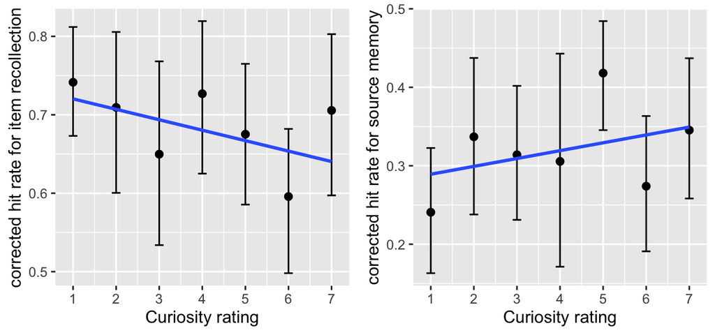

### 1.2.1 Item recollection

#### 1.2.1.1 Correlation with the average score

```
##                  Model df       AIC       BIC   logLik   Test  L.Ratio
## baseline.rating      1  3 -65.61892 -56.35613 35.80946
## rating.intercept     2  4 -69.78735 -57.43697 38.89368 1 vs 2 6.168437
## rating.slope         3  6 -65.78386 -47.25828 38.89193 2 vs 3 0.003494
## tr.intercept         4  7 -66.74930 -45.13613 40.37465 3 vs 4 2.965442
## tr.slope             5  8 -64.75036 -40.04959 40.37518 4 vs 5 0.001063
##                  p-value
## baseline.rating
## rating.intercept  0.0130
## rating.slope      0.9983
## tr.intercept      0.0851
## tr.slope          0.9740
```

#### 1.2.1.2 Correlation with the PC score

```
##                  Model df       AIC       BIC   logLik   Test  L.Ratio
## baseline.rating      1  3 -65.61892 -56.35613 35.80946
## rating.intercept     2  4 -69.78735 -57.43697 38.89368 1 vs 2 6.168437
## rating.slope         3  6 -65.78386 -47.25828 38.89193 2 vs 3 0.003494
## PC.intercept         4  7 -67.55338 -45.94020 40.77669 3 vs 4 3.769518
## PC.slope             5  8 -65.55511 -40.85434 40.77755 4 vs 5 0.001730
##                  p-value
## baseline.rating
## rating.intercept  0.0130
## rating.slope      0.9983
## PC.intercept      0.0522
## PC.slope          0.9668
```

```
##                   Value   Std.Error  DF   t-value      p-value
## (Intercept)  1.19489487 0.230968973 134  5.173400 8.194223e-07
## CurRating   -0.01585688 0.006306131 134 -2.514517 1.310235e-02
## PC          -0.16102981 0.080786305  25 -1.993281 5.725145e-02
```

#### 1.2.1.3 Correlation with the EC score

```
##                  Model df       AIC       BIC   logLik   Test  L.Ratio
## baseline.rating      1  3 -65.61892 -56.35613 35.80946
## rating.intercept     2  4 -69.78735 -57.43697 38.89368 1 vs 2 6.168437
## rating.slope         3  6 -65.78386 -47.25828 38.89193 2 vs 3 0.003494
## EC.intercept         4  7 -65.15909 -43.54591 39.57954 3 vs 4 1.375227
## EC.slope             5  8 -63.16642 -38.46565 39.58321 4 vs 5 0.007333
##                  p-value
## baseline.rating
## rating.intercept  0.0130
## rating.slope      0.9983
## EC.intercept      0.2409
## EC.slope          0.9318
```

### 1.2.2 Source memory

#### 1.2.2.1 Correlation with the average score

```
##                  Model df       AIC        BIC   logLik   Test  L.Ratio
## baseline.rating      1  3 -25.99578 -16.732992 15.99789
## rating.intercept     2  4 -25.09750 -12.747119 16.54875 1 vs 2 1.101723
## rating.slope         3  6 -23.47161  -4.946029 17.73580 2 vs 3 2.374104
## tr.intercept         4  7 -26.59176  -4.978587 20.29588 3 vs 4 5.120154
## tr.slope             5  8 -24.81119  -0.110421 20.40560 4 vs 5 0.219430
##                  p-value
## baseline.rating
## rating.intercept  0.2939
## rating.slope      0.3051
## tr.intercept      0.0236
## tr.slope          0.6395
```

#### 1.2.2.2 Correlation with the PC score

```
##                  Model df       AIC        BIC   logLik   Test  L.Ratio
## baseline.rating      1  3 -25.99578 -16.732992 15.99789
## rating.intercept     2  4 -25.09750 -12.747119 16.54875 1 vs 2 1.101723
## rating.slope         3  6 -23.47161  -4.946029 17.73580 2 vs 3 2.374104
## PC.intercept         4  7 -29.10988  -7.496702 21.55494 3 vs 4 7.638269
## PC.slope             5  8 -27.48051  -2.779739 21.74026 4 vs 5 0.370633
##                  p-value
## baseline.rating
## rating.intercept  0.2939
## rating.slope      0.3051
## PC.intercept      0.0057
## PC.slope          0.5427
```

```
##                    Value   Std.Error  DF    t-value      p-value
## (Intercept)  0.701919253 0.148041284 134  4.7413751 5.354813e-06
## CurRating    0.008170695 0.008548807 134  0.9557702 3.409095e-01
## PC          -0.148484104 0.051158727  25 -2.9024198 7.623819e-03
```

#### 1.2.2.3 Correlation with the EC score

```
##                  Model df       AIC        BIC   logLik   Test   L.Ratio
## baseline.rating      1  3 -25.99578 -16.732992 15.99789
## rating.intercept     2  4 -25.09750 -12.747119 16.54875 1 vs 2 1.1017228
## rating.slope         3  6 -23.47161  -4.946029 17.73580 2 vs 3 2.3741036
## EC.intercept         4  7 -23.36437  -1.751200 18.68219 3 vs 4 1.8927670
## EC.slope             5  8 -21.42334   3.277430 18.71167 4 vs 5 0.0589663
##                  p-value
## baseline.rating
## rating.intercept  0.2939
## rating.slope      0.3051
## EC.intercept      0.1689
## EC.slope          0.8081
```

# 2 Relationship between trait score and curiosity ratings

## 2.1 Across all the rooms

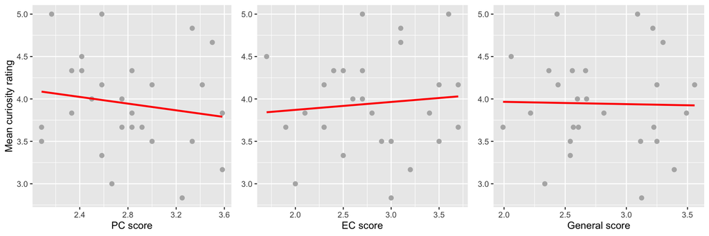

```r
cor.test(trait.ratings$meanCurRating, trait.ratings$PC, method = "pearson")
```

```
##
##  Pearson's product-moment correlation
##
## data:  trait.ratings$meanCurRating and trait.ratings$PC
## t = -0.79392, df = 25, p-value = 0.4347
## alternative hypothesis: true correlation is not equal to 0
## 95 percent confidence interval:
##  -0.5066409  0.2373384
## sample estimates:
##        cor
## -0.1568194
```

```r
cor.test(trait.ratings$meanCurRating, trait.ratings$EC, method = "pearson")
```

```
##
##  Pearson's product-moment correlation
##
## data:  trait.ratings$meanCurRating and trait.ratings$EC
## t = 0.46403, df = 25, p-value = 0.6466
## alternative hypothesis: true correlation is not equal to 0
## 95 percent confidence interval:
##  -0.2980717  0.4563964
## sample estimates:
##        cor
## 0.09240966
```

```r
cor.test(trait.ratings$meanCurRating, trait.ratings$GN, method = "pearson")
```

```
##
##  Pearson's product-moment correlation
##
## data:  trait.ratings$meanCurRating and trait.ratings$GN
## t = -0.10549, df = 25, p-value = 0.9168
## alternative hypothesis: true correlation is not equal to 0
## 95 percent confidence interval:
##  -0.3979185  0.3618201
## sample estimates:
##         cor
## -0.02109429
```

## 2.2 Only for the *novel* rooms

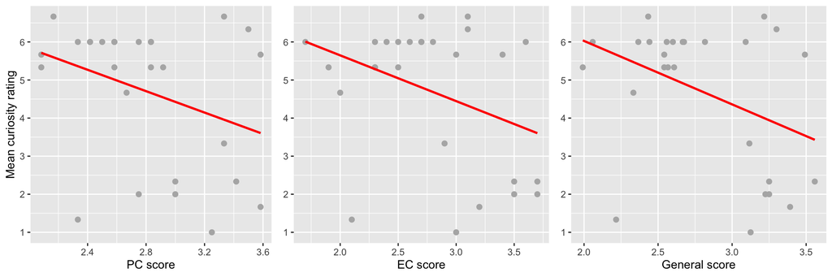

```
##
##  Pearson's product-moment correlation
##
## data:  trait.ratings.novel$meanCurRating and trait.ratings.novel$PC
## t = -1.8167, df = 25, p-value = 0.08127
## alternative hypothesis: true correlation is not equal to 0
## 95 percent confidence interval:
##  -0.63863186  0.04426315
## sample estimates:
##       cor
## -0.341495
```

```
##
##  Pearson's product-moment correlation
##
## data:  trait.ratings.novel$meanCurRating and trait.ratings.novel$EC
## t = -1.9532, df = 25, p-value = 0.06207
## alternative hypothesis: true correlation is not equal to 0
## 95 percent confidence interval:
##  -0.65351622  0.01873808
## sample estimates:
##        cor
## -0.3638669
```

```
##
##  Pearson's product-moment correlation
##
## data:  trait.ratings.novel$meanCurRating and trait.ratings.novel$GN
## t = -2.19, df = 25, p-value = 0.03807
## alternative hypothesis: true correlation is not equal to 0
## 95 percent confidence interval:
##  -0.67786629 -0.02499858
## sample estimates:
##        cor
## -0.4012012
```

# 3 Relationship between trait score and memory performance

Here *memory performance* refers to the average corrected hit rate for “seen” response for items and average corrected hit rate for source memory.

## 3.1 Outside

### 3.1.1 Item recollection

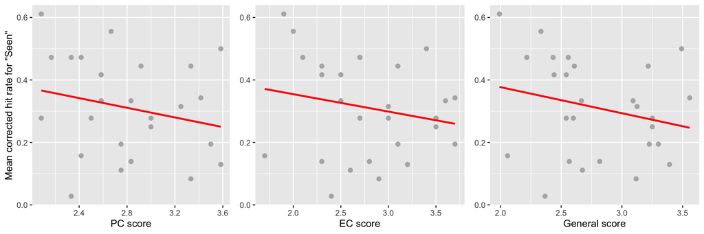

```
##
##  Pearson's product-moment correlation
##
## data:  outside.hit.rate.trait$meanSAcc and outside.hit.rate.trait$PC
## t = -1.1439, df = 25, p-value = 0.2635
## alternative hypothesis: true correlation is not equal to 0
## 95 percent confidence interval:
##  -0.5559136  0.1715395
## sample estimates:
##       cor
## -0.223012
```

```
##
##  Pearson's product-moment correlation
##
## data:  outside.hit.rate.trait$meanSAcc and outside.hit.rate.trait$EC
## t = -1.0223, df = 25, p-value = 0.3164
## alternative hypothesis: true correlation is not equal to 0
## 95 percent confidence interval:
##  -0.5392813  0.1945005
## sample estimates:
##        cor
## -0.2003197
```

```
##
##  Pearson's product-moment correlation
##
## data:  outside.hit.rate.trait$meanSAcc and outside.hit.rate.trait$GN
## t = -1.2282, df = 25, p-value = 0.2308
## alternative hypothesis: true correlation is not equal to 0
## 95 percent confidence interval:
##  -0.5671519  0.1555644
## sample estimates:
##       cor
## -0.238552
```

### 3.1.2 Source memory

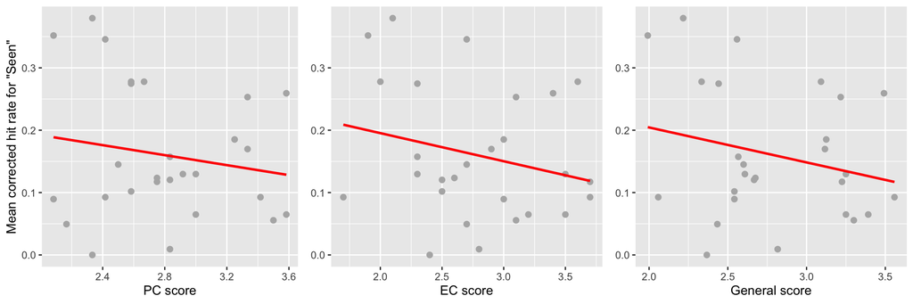

```
##
##  Pearson's product-moment correlation
##
## data:  outside.hit.rate.trait$meanSrcAcc and outside.hit.rate.trait$PC
## t = -0.87061, df = 25, p-value = 0.3923
## alternative hypothesis: true correlation is not equal to 0
## 95 percent confidence interval:
##  -0.5178004  0.2230108
## sample estimates:
##        cor
## -0.1715407
```

```
##
##  Pearson's product-moment correlation
##
## data:  outside.hit.rate.trait$meanSrcAcc and outside.hit.rate.trait$EC
## t = -1.2368, df = 25, p-value = 0.2277
## alternative hypothesis: true correlation is not equal to 0
## 95 percent confidence interval:
##  -0.568277  0.153944
## sample estimates:
##        cor
## -0.2401171
```

```
##
##  Pearson's product-moment correlation
##
## data:  outside.hit.rate.trait$meanSrcAcc and outside.hit.rate.trait$GN
## t = -1.2229, df = 25, p-value = 0.2328
## alternative hypothesis: true correlation is not equal to 0
## 95 percent confidence interval:
##  -0.5664524  0.1565698
## sample estimates:
##        cor
## -0.2375798
```

## 3.2 Inside

### 3.2.1 Item recollection

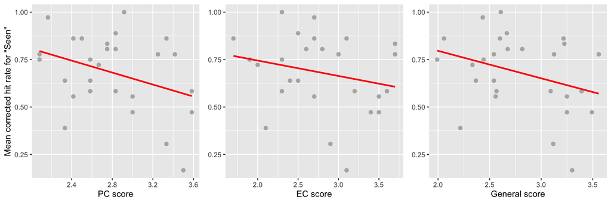

```
##
##  Pearson's product-moment correlation
##
## data:  inside.hit.rate.trait$meanSAcc and inside.hit.rate.trait$PC
## t = -1.9004, df = 25, p-value = 0.06898
## alternative hypothesis: true correlation is not equal to 0
## 95 percent confidence interval:
##  -0.64782767  0.02859789
## sample estimates:
##        cor
## -0.3552771
```

```
##
##  Pearson's product-moment correlation
##
## data:  inside.hit.rate.trait$meanSAcc and inside.hit.rate.trait$EC
## t = -1.1693, df = 25, p-value = 0.2533
## alternative hypothesis: true correlation is not equal to 0
## 95 percent confidence interval:
##  -0.5593320  0.1667204
## sample estimates:
##        cor
## -0.2277211
```

```
##
##  Pearson's product-moment correlation
##
## data:  inside.hit.rate.trait$meanSAcc and inside.hit.rate.trait$GN
## t = -1.7039, df = 25, p-value = 0.1008
## alternative hypothesis: true correlation is not equal to 0
## 95 percent confidence interval:
##  -0.62586423  0.06547014
## sample estimates:
##        cor
## -0.3225692
```

### 3.2.2 Source memory

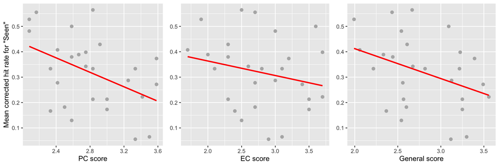

```
##
##  Pearson's product-moment correlation
##
## data:  inside.hit.rate.trait$meanSrcAcc and inside.hit.rate.trait$PC
## t = -2.5522, df = 25, p-value = 0.0172
## alternative hypothesis: true correlation is not equal to 0
## 95 percent confidence interval:
##  -0.71169063 -0.09020356
## sample estimates:
##        cor
## -0.4546333
```

```
##
##  Pearson's product-moment correlation
##
## data:  inside.hit.rate.trait$meanSrcAcc and inside.hit.rate.trait$EC
## t = -1.1663, df = 25, p-value = 0.2545
## alternative hypothesis: true correlation is not equal to 0
## 95 percent confidence interval:
##  -0.5589280  0.1672918
## sample estimates:
##        cor
## -0.2271637
```

```
##
##  Pearson's product-moment correlation
##
## data:  inside.hit.rate.trait$meanSrcAcc and inside.hit.rate.trait$GN
## t = -2.0063, df = 25, p-value = 0.05576
## alternative hypothesis: true correlation is not equal to 0
## 95 percent confidence interval:
##  -0.659129328  0.008879163
## sample estimates:
##        cor
## -0.3723913
```

# 4 Relationship between trait score and memory performance within *Novel* rooms

Here *memory performance* refers to the average corrected hit rate for “seen” response for items and average corrected hit rate for source memory.

## 4.1 Outside

### 4.1.1 Item recollection

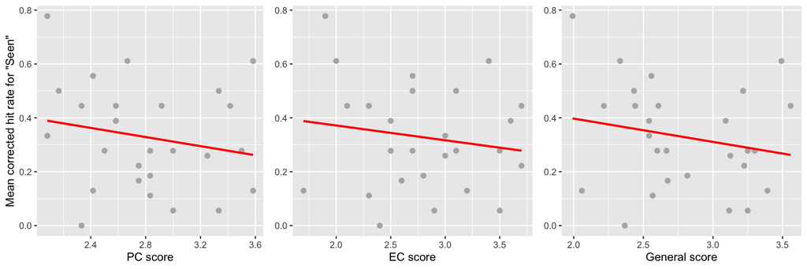

```
##
##  Pearson's product-moment correlation
##
## data:  outside.hit.rate.trait.novel$meanSAcc and outside.hit.rate.trait.novel$PC
## t = -1.0052, df = 25, p-value = 0.3244
## alternative hypothesis: true correlation is not equal to 0
## 95 percent confidence interval:
##  -0.536898  0.197726
## sample estimates:
##        cor
## -0.1970976
```

```
##
##  Pearson's product-moment correlation
##
## data:  outside.hit.rate.trait.novel$meanSAcc and outside.hit.rate.trait.novel$EC
## t = -0.80686, df = 25, p-value = 0.4274
## alternative hypothesis: true correlation is not equal to 0
## 95 percent confidence interval:
##  -0.5085381  0.2349252
## sample estimates:
##        cor
## -0.1593113
```

```
##
##  Pearson's product-moment correlation
##
## data:  outside.hit.rate.trait.novel$meanSAcc and outside.hit.rate.trait.novel$GN
## t = -1.0189, df = 25, p-value = 0.318
## alternative hypothesis: true correlation is not equal to 0
## 95 percent confidence interval:
##  -0.5388121  0.1951367
## sample estimates:
##        cor
## -0.1996848
```

### 4.1.2 Source memory

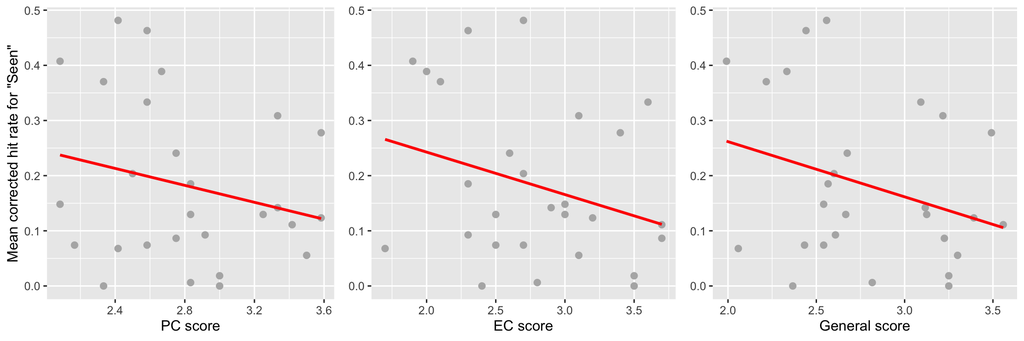

```
##
##  Pearson's product-moment correlation
##
## data:  outside.hit.rate.trait.novel$meanSrcAcc and outside.hit.rate.trait.novel$PC
## t = -1.2254, df = 25, p-value = 0.2318
## alternative hypothesis: true correlation is not equal to 0
## 95 percent confidence interval:
##  -0.5667796  0.1560997
## sample estimates:
##        cor
## -0.2380345
```

```
##
##  Pearson's product-moment correlation
##
## data:  outside.hit.rate.trait.novel$meanSrcAcc and outside.hit.rate.trait.novel$EC
## t = -1.5563, df = 25, p-value = 0.1322
## alternative hypothesis: true correlation is not equal to 0
## 95 percent confidence interval:
##  -0.60849236  0.09335552
## sample estimates:
##        cor
## -0.2972021
```

```
##
##  Pearson's product-moment correlation
##
## data:  outside.hit.rate.trait.novel$meanSrcAcc and outside.hit.rate.trait.novel$GN
## t = -1.6132, df = 25, p-value = 0.1193
## alternative hypothesis: true correlation is not equal to 0
## 95 percent confidence interval:
##  -0.61526899  0.08260708
## sample estimates:
##        cor
## -0.3070456
```

## 4.2 Inside

### 4.2.1 Item recollection

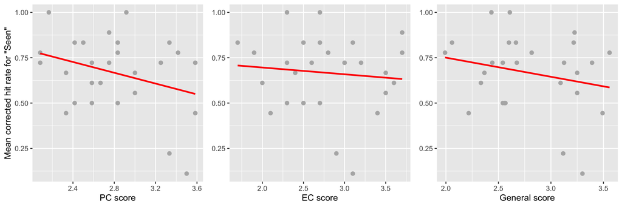

```
##
##  Pearson's product-moment correlation
##
## data:  inside.hit.rate.trait.novel$meanSAcc and inside.hit.rate.trait.novel$PC
## t = -1.7077, df = 25, p-value = 0.1001
## alternative hypothesis: true correlation is not equal to 0
## 95 percent confidence interval:
##  -0.62630266  0.06475212
## sample estimates:
##        cor
## -0.3232151
```

```
##
##  Pearson's product-moment correlation
##
## data:  inside.hit.rate.trait.novel$meanSAcc and inside.hit.rate.trait.novel$EC
## t = -0.50681, df = 25, p-value = 0.6167
## alternative hypothesis: true correlation is not equal to 0
## 95 percent confidence interval:
##  -0.4631121  0.2902929
## sample estimates:
##       cor
## -0.100846
```

```
##
##  Pearson's product-moment correlation
##
## data:  inside.hit.rate.trait.novel$meanSAcc and inside.hit.rate.trait.novel$GN
## t = -1.1633, df = 25, p-value = 0.2557
## alternative hypothesis: true correlation is not equal to 0
## 95 percent confidence interval:
##  -0.5585303  0.1678537
## sample estimates:
##        cor
## -0.2266153
```

### 4.2.2 Source memory

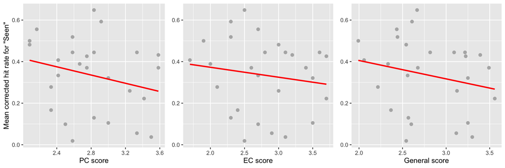

```
##
##  Pearson's product-moment correlation
##
## data:  inside.hit.rate.trait.novel$meanSrcAcc and inside.hit.rate.trait.novel$PC
## t = -1.3053, df = 25, p-value = 0.2037
## alternative hypothesis: true correlation is not equal to 0
## 95 percent confidence interval:
##  -0.5771996  0.1409542
## sample estimates:
##        cor
## -0.2525896
```

```
##
##  Pearson's product-moment correlation
##
## data:  inside.hit.rate.trait.novel$meanSrcAcc and inside.hit.rate.trait.novel$EC
## t = -0.76894, df = 25, p-value = 0.4491
## alternative hypothesis: true correlation is not equal to 0
## 95 percent confidence interval:
##  -0.5029622  0.2419914
## sample estimates:
##        cor
## -0.1520005
```

```
##
##  Pearson's product-moment correlation
##
## data:  inside.hit.rate.trait.novel$meanSrcAcc and inside.hit.rate.trait.novel$GN
## t = -1.1444, df = 25, p-value = 0.2633
## alternative hypothesis: true correlation is not equal to 0
## 95 percent confidence interval:
##  -0.5559854  0.1714386
## sample estimates:
##        cor
## -0.2231108
```

# 5 Relationship between trait score and curiosity ratings between *Familiar* and *Novel* rooms

## 5.1 See whether the curiosity ratings are significantly different between *novel* and *familiar* rooms

The average curiosity rating for the *novel* rooms is 4.7 (SD = $\pm$ 1.87).

The average curiosity rating for the *familiar* rooms is 3.19 (SD = $\pm$ 1.55).

```
##
##  One Sample t-test
##
## data:  outside.hit.rate.trait.diff$diffRating
## t = 2.4352, df = 26, p-value = 0.02205
## alternative hypothesis: true mean is not equal to 0
## 95 percent confidence interval:
##  0.2367577 2.8002794
## sample estimates:
## mean of x
##  1.518519
```

## 5.2 See whether the difference in curiosity ratings are significantly correlated with trait scores

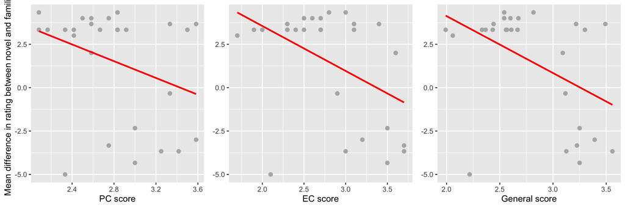

```
##
##  Pearson's product-moment correlation
##
## data:  outside.hit.rate.trait.diff$diffRating and outside.hit.rate.trait.diff$PC
## t = -1.8012, df = 25, p-value = 0.08374
## alternative hypothesis: true correlation is not equal to 0
## 95 percent confidence interval:
##  -0.63690750  0.04716371
## sample estimates:
##        cor
## -0.3389248
```

```
##
##  Pearson's product-moment correlation
##
## data:  outside.hit.rate.trait.diff$diffRating and outside.hit.rate.trait.diff$EC
## t = -2.5386, df = 25, p-value = 0.01773
## alternative hypothesis: true correlation is not equal to 0
## 95 percent confidence interval:
##  -0.71049613 -0.08780639
## sample estimates:
##        cor
## -0.4527143
```

```
##
##  Pearson's product-moment correlation
##
## data:  outside.hit.rate.trait.diff$diffRating and outside.hit.rate.trait.diff$GN
## t = -2.5602, df = 25, p-value = 0.01689
## alternative hypothesis: true correlation is not equal to 0
## 95 percent confidence interval:
##  -0.71239100 -0.09161246
## sample estimates:
##        cor
## -0.4557596
```

### 5.2.1 Looking at the trait-rating correlation separately for the *novel* and *familiar* rooms

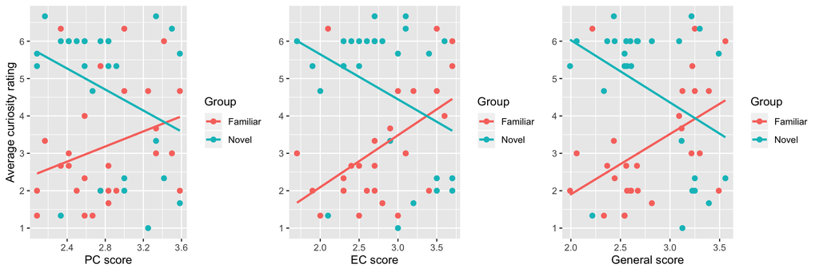

# 6 Relationship between trait score and performance differences between *Familiar* and *Novel* rooms

Here *performance difference* refers to difference in item recollection and source memory between the *novel* and *familiar* rooms (*novel* - *familiar*).

## 6.1 Outside

### 6.1.1 Item recollection

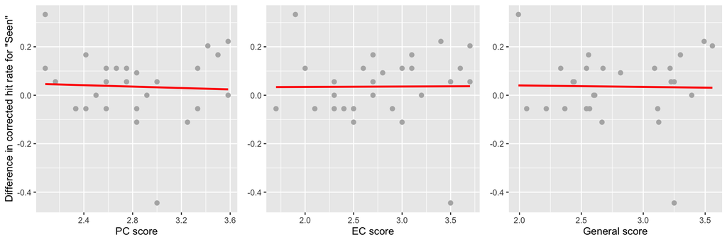

### 6.1.2 Source memory

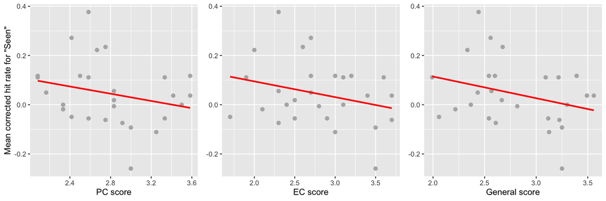

```
##
##  Pearson's product-moment correlation
##
## data:  outside.hit.rate.trait.diff$diffSrcAcc and outside.hit.rate.trait.diff$PC
## t = -1.2977, df = 25, p-value = 0.2062
## alternative hypothesis: true correlation is not equal to 0
## 95 percent confidence interval:
##  -0.5762261  0.1423836
## sample estimates:
##        cor
## -0.2512235
```

```
##
##  Pearson's product-moment correlation
##
## data:  outside.hit.rate.trait.diff$diffSrcAcc and outside.hit.rate.trait.diff$EC
## t = -1.4145, df = 25, p-value = 0.1695
## alternative hypothesis: true correlation is not equal to 0
## 95 percent confidence interval:
##  -0.5910859  0.1202341
## sample estimates:
##        cor
## -0.2722177
```

```
##
##  Pearson's product-moment correlation
##
## data:  outside.hit.rate.trait.diff$diffSrcAcc and outside.hit.rate.trait.diff$GN
## t = -1.5609, df = 25, p-value = 0.1311
## alternative hypothesis: true correlation is not equal to 0
## 95 percent confidence interval:
##  -0.60904242  0.09248914
## sample estimates:
##        cor
## -0.2979986
```

## 6.2 Inside

### 6.2.1 Item recollection

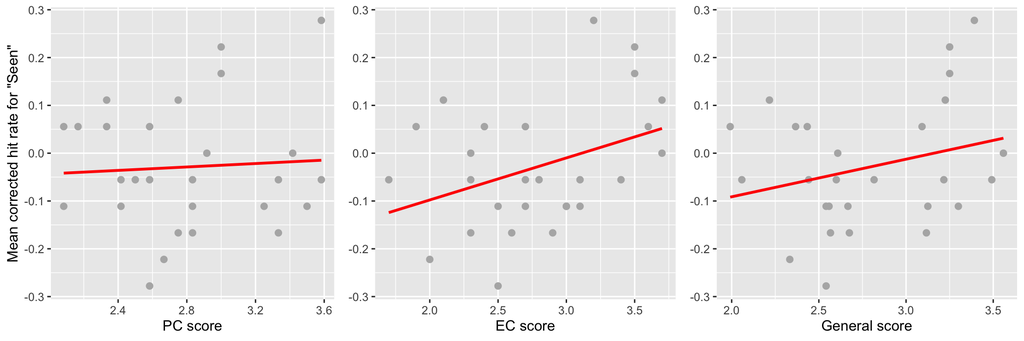

```
##
##  Pearson's product-moment correlation
##
## data:  inside.hit.rate.trait.diff$diffSAcc and inside.hit.rate.trait.diff$PC
## t = 0.30725, df = 25, p-value = 0.7612
## alternative hypothesis: true correlation is not equal to 0
## 95 percent confidence interval:
##  -0.3262846  0.4312957
## sample estimates:
##        cor
## 0.06133438
```

```
##
##  Pearson's product-moment correlation
##
## data:  inside.hit.rate.trait.diff$diffSAcc and inside.hit.rate.trait.diff$EC
## t = 2.0207, df = 25, p-value = 0.05414
## alternative hypothesis: true correlation is not equal to 0
## 95 percent confidence interval:
##  -0.006193439  0.660645635
## sample estimates:
##       cor
## 0.3747024
```

```
##
##  Pearson's product-moment correlation
##
## data:  inside.hit.rate.trait.diff$diffSAcc and inside.hit.rate.trait.diff$GN
## t = 1.3827, df = 25, p-value = 0.179
## alternative hypothesis: true correlation is not equal to 0
## 95 percent confidence interval:
##  -0.1262642  0.5870876
## sample estimates:
##       cor
## 0.2665389
```

### 6.2.2 Source memory

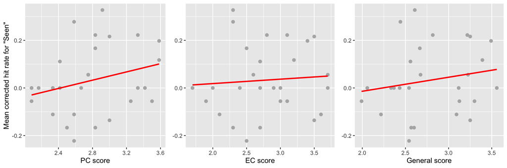

```
##
##  Pearson's product-moment correlation
##
## data:  inside.hit.rate.trait.diff$diffSrcAcc and inside.hit.rate.trait.diff$PC
## t = 1.399, df = 25, p-value = 0.1741
## alternative hypothesis: true correlation is not equal to 0
## 95 percent confidence interval:
##  -0.1231757  0.5891398
## sample estimates:
##       cor
## 0.2694508
```

```
##
##  Pearson's product-moment correlation
##
## data:  inside.hit.rate.trait.diff$diffSrcAcc and inside.hit.rate.trait.diff$EC
## t = 0.3596, df = 25, p-value = 0.7222
## alternative hypothesis: true correlation is not equal to 0
## 95 percent confidence interval:
##  -0.3169176  0.4397615
## sample estimates:
##        cor
## 0.07173567
```

```
##
##  Pearson's product-moment correlation
##
## data:  inside.hit.rate.trait.diff$diffSrcAcc and inside.hit.rate.trait.diff$GN
## t = 0.92106, df = 25, p-value = 0.3658
## alternative hypothesis: true correlation is not equal to 0
## 95 percent confidence interval:
##  -0.2135512  0.5250327
## sample estimates:
##       cor
## 0.1811647
```